# Sesiones 8–9: Chi-Cuadrado y Regresión Lineal Simple

Curso de Estadística — Pontificia Universidad Javeriana

Prof. Jaime Polanco Jiménez

2026-10-16

# 1 Cargar datos

Antes de empezar, cargamos los datos de ICFES (Saber Pro y Saber 11) desde el repositorio del curso.

```r
library(arrow)
library(dplyr)
library(ggplot2)

gh <- paste0(
  "https://raw.githubusercontent.com/",
  "polanco-jaime/Curso-Estadistica-2026-3/",
  "main/datos"
)

# Saber Pro
saber_pro <- read_parquet(paste0(gh, "/saber_pro/saber_pro.parquet"))

# Crear variable de tipo de IES (privada vs pública)
saber_pro$TIPO_IES <- ifelse(
  grepl("NO OFICIAL", saber_pro$INST_ORIGEN),
  "Privada", "Publica"
)
```

Veamos las primeras filas y las variables disponibles:

```r
glimpse(saber_pro)
```

```
## Rows: 1,216,721
## Columns: 27
## $ ESTU_CONSECUTIVO          <chr> "EK202030264202", "EK202030264158", "EK20203…
## $ PERIODO                   <dbl> 20203, 20203, 20203, 20203, 20203, 20203, 20…
## $ ESTU_GENERO               <chr> "M", "F", "F", "M", "M", "M", "M", "F", "F",…
## $ ESTU_FECHANACIMIENTO      <chr> "11/12/1997", "05/12/1998", "14/05/1997", "0…
## $ ESTU_DEPTO_RESIDE         <chr> "VALLE", "VALLE", "VALLE", "VALLE", "CAUCA",…
## $ ESTU_MCPIO_RESIDE         <chr> "JAMUNDÍ", "CALI", "CALI", "CALI", "POPAYÁN"…
## $ ESTU_ZONA_RESIDE          <chr> "Area Rural", "Cabecera Municipal", "Cabecer…
## $ FAMI_ESTRATOVIVIENDA      <chr> "Estrato 5", "Estrato 5", "Estrato 5", "Estr…
## $ FAMI_EDUCACIONPADRE       <chr> "Postgrado", "Educación profesional completa…
## $ FAMI_EDUCACIONMADRE       <chr> "Postgrado", "Educación profesional completa…
## $ FAMI_TIENEINTERNET        <chr> "Si", "Si", "Si", "Si", "Si", "Si", "No", "S…
## $ FAMI_TIENECOMPUTADOR      <chr> "Si", "Si", "Si", "Si", "Si", "Si", "Si", "S…
## $ FAMI_TIENEAUTOMOVIL       <chr> "Si", "Si", "Si", "Si", "Si", "Si", "No", "S…
## $ FAMI_TIENELAVADORA        <chr> "Si", "Si", "Si", "Si", "Si", "Si", "Si", "S…
## $ INST_NOMBRE_INSTITUCION   <chr> "UNIVERSIDAD ICESI-CALI", "UNIVERSIDAD ICESI…
## $ INST_ORIGEN               <chr> "NO OFICIAL - CORPORACIÓN", "NO OFICIAL - CO…
## $ INST_CARACTER_ACADEMICO   <chr> "UNIVERSIDAD", "UNIVERSIDAD", "UNIVERSIDAD",…
## $ ESTU_METODO_PRGM          <chr> "PRESENCIAL", "PRESENCIAL", "PRESENCIAL", "P…
## $ ESTU_PRGM_ACADEMICO       <chr> "MERCADEO INTERNACIONAL Y PUBLICIDAD", "MERC…
## $ ESTU_SNIES_PRGMACADEMICO  <dbl> 21548, 21548, 21548, 21548, 21548, 21548, 21…
## $ MOD_RAZONA_CUANTITAT_PUNT <dbl> 170, 144, 181, 177, 191, 181, 190, 165, 146,…
## $ MOD_LECTURA_CRITICA_PUNT  <dbl> 175, 111, 177, 179, 150, 172, 187, 183, 141,…
## $ MOD_COMPETEN_CIUDADA_PUNT <dbl> 185, 149, 141, 174, 195, 166, 195, 192, 142,…
## $ MOD_INGLES_PUNT           <dbl> 199, 189, 188, 215, 171, 200, 216, 218, 172,…
## $ MOD_INGLES_DESEM          <chr> "B1", "B1", "B1", "B2", "B1", "B2", "B2", "B…
## $ PUNT_GLOBAL               <dbl> 206, 146, 163, 175, 181, 176, 191, 187, 153,…
## $ TIPO_IES                  <chr> "Privada", "Privada", "Privada", "Privada", …
```

# 2 Parte 1: Chi-Cuadrado

## 2.1 ¿Qué hacemos con variables categóricas?

Todo lo que hemos visto hasta ahora son **casos especiales de OLS**. Pero ¿qué pasa cuando **ambas** variables son categóricas?

| Situación | Modelo OLS equivalente |
| --- | --- |
| 2 grupos | $Y = \beta_0 + \beta_1 D + \varepsilon$ (= “t-test”) |
| 3+ grupos | $Y = \beta_0 + \sum \beta_k D_k + \varepsilon$ (= “ANOVA”) |
| X continua | $Y = \beta_0 + \beta_1 X + \varepsilon$ (regresión clásica) |
| **Ambas categóricas** | **Chi-cuadrado (no es OLS)** |

## 2.2 Ejemplo a mano: género y aprobación

Imaginemos 10 estudiantes (5 hombres, 5 mujeres) con notas en un examen de matemáticas:

```r
hombres <- c(82, 78, 91, 85, 74)
mujeres <- c(76, 80, 72, 85, 77)

# Convertir a aprobado/reprobado (corte en 80)
tabla_mano <- matrix(
  c(3, 2, 2, 3),
  nrow = 2, byrow = TRUE,
  dimnames = list(
    Genero = c("Hombres", "Mujeres"),
    Resultado = c("Aprobó", "Reprobó")
  )
)
tabla_mano
```

```
##          Resultado
## Genero    Aprobó Reprobó
##   Hombres      3       2
##   Mujeres      2       3
```

### 2.2.1 Frecuencias esperadas bajo independencia

Si género y aprobación fueran **independientes**, esperaríamos:

$$E_{ij} = \frac{\text{Total fila}_i
\times \text{Total columna}_j}{n}$$

```r
n <- sum(tabla_mano)
total_filas <- rowSums(tabla_mano)
total_cols  <- colSums(tabla_mano)

esperadas <- outer(total_filas, total_cols) / n
esperadas
```

```
##         Aprobó Reprobó
## Hombres    2.5     2.5
## Mujeres    2.5     2.5
```

### 2.2.2 Estadístico chi-cuadrado

$$\chi^2 = \sum \frac{(O_{ij} -
E_{ij})^2}{E_{ij}}$$

```r
chi2 <- sum((tabla_mano - esperadas)^2 / esperadas)
chi2
```

```
## [1] 0.4
```

```r
# Grados de libertad: (r-1)(c-1)
gl <- (nrow(tabla_mano) - 1) * (ncol(tabla_mano) - 1)
gl
```

```
## [1] 1
```

```r
# p-valor
pchisq(chi2, df = gl, lower.tail = FALSE)
```

```
## [1] 0.5270893
```

Con $\chi^2 = 0.40$ y $\text{gl} = 1$, el p-valor es muy alto. **No rechazamos $H_0$**: no hay evidencia de asociación entre género y aprobación.

> **Ojo**: Con $n = 10$, las frecuencias esperadas son 2.5 (< 5). La aproximación $\chi^2$ no es confiable. Usaríamos la prueba exacta de Fisher:

```r
fisher.test(tabla_mano)
```

```
##
##  Fisher's Exact Test for Count Data
##
## data:  tabla_mano
## p-value = 1
## alternative hypothesis: true odds ratio is not equal to 1
## 95 percent confidence interval:
##   0.1060478 51.7634048
## sample estimates:
## odds ratio
##   2.069959
```

## 2.3 Prueba de independencia con datos ICFES

¿El nivel de inglés MCER es **independiente** del tipo de IES (pública/privada)?

```r
tabla_obs <- table(saber_pro$MOD_INGLES_DESEM, saber_pro$TIPO_IES)
tabla_obs
```

```
##
##       Privada Publica
##   -A1   76936   42076
##   A1   173225   87315
##   A2   302125  157512
##   B1   172803   86147
##   B2    85205   33254
```

### 2.3.1 Aplicar `chisq.test()`

```r
resultado <- chisq.test(tabla_obs)
resultado
```

```
##
##  Pearson's Chi-squared test
##
## data:  tabla_obs
## X-squared = 1875.6, df = 4, p-value < 2.2e-16
```

### 2.3.2 Frecuencias esperadas

```r
round(resultado$expected, 1)
```

```
##
##        Privada  Publica
##   -A1  79265.9  39746.1
##   A1  173528.1  87011.9
##   A2  306133.3 153503.7
##   B1  172469.2  86480.8
##   B2   78897.6  39561.4
```

### 2.3.3 Residuos estandarizados

Los residuos nos dicen **dónde** están las diferencias más importantes. Valores con $|r| > 2$ indican celdas con diferencias relevantes.

```r
round(resultado$residuals, 2)
```

```
##
##       Privada Publica
##   -A1   -8.28   11.69
##   A1    -0.73    1.03
##   A2    -7.24   10.23
##   B1     0.80   -1.14
##   B2    22.46  -31.71
```

### 2.3.4 Visualizar la asociación

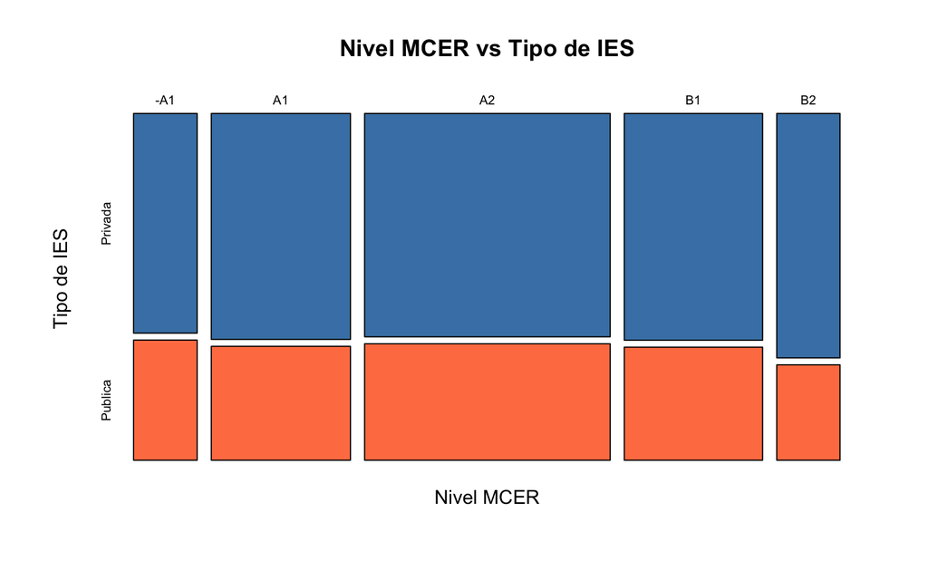

```r
mosaicplot(tabla_obs,
           color = c("steelblue", "coral"),
           main = "Nivel MCER vs Tipo de IES",
           xlab = "Nivel MCER",
           ylab = "Tipo de IES")
```

## 2.4 V de Cramér: tamaño del efecto

Así como la $d$ de Cohen mide la magnitud para medias, la **V de Cramér** mide la fuerza de la asociación entre variables categóricas:

$$V = \sqrt{\frac{\chi^2}{n \times
(\min(r,c) - 1)}}$$

```r
chi2_val <- resultado$statistic
n_obs    <- sum(tabla_obs)
min_dim  <- min(nrow(tabla_obs), ncol(tabla_obs))

V <- sqrt(chi2_val / (n_obs * (min_dim - 1)))
V
```

```
##  X-squared
## 0.03926405
```

| Valor de V | Interpretación |
| --- | --- |
| $< 0.1$ | Muy débil |
| $0.1 - 0.3$ | Moderada |
| $\geq 0.3$ | Fuerte |

## 2.5 Bondad de ajuste

La prueba de **independencia** compara dos variables categóricas. La prueba de **bondad de ajuste** compara una variable observada contra una distribución teórica.

**Pregunta**: ¿Los 5 niveles MCER se distribuyen uniformemente?

```r
niveles <- table(saber_pro$MOD_INGLES_DESEM)
niveles
```

```
##
##    -A1     A1     A2     B1     B2
## 119012 260540 459637 258950 118459
```

```r
# Si fuera uniforme, esperaríamos n/5 en cada nivel
chisq.test(niveles, p = rep(1/5, 5))
```

```
##
##  Chi-squared test for given probabilities
##
## data:  niveles
## X-squared = 322114, df = 4, p-value < 2.2e-16
```

**Conclusión**: Rechazamos $H_0$. La distribución **no** es uniforme.

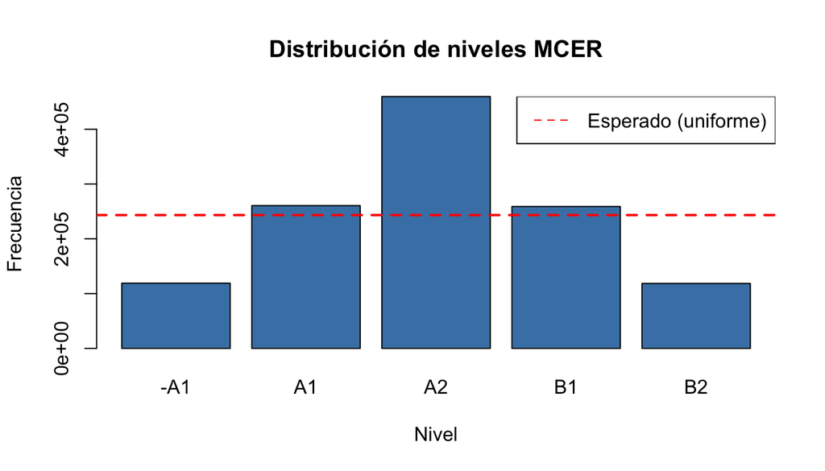

```r
barplot(niveles,
        col = "steelblue",
        main = "Distribución de niveles MCER",
        xlab = "Nivel", ylab = "Frecuencia")
abline(h = sum(niveles) / 5, col = "red", lty = 2, lwd = 2)
legend("topright", "Esperado (uniforme)", col = "red", lty = 2)
```

# 3 Parte 2: Regresión Lineal Simple (OLS)

## 3.1 Preparar datos: cruzar Saber Pro y Saber 11

Para la regresión necesitamos variables de ambos exámenes. Cruzamos los datos usando la tabla de cruce:

```r
s11 <- read_parquet(paste0(gh, "/saber11/saber11.parquet"))
cr  <- read_parquet(paste0(gh, "/cruce/cruce_saber11_saberpro.parquet"))

saber_pro <- saber_pro |>
  inner_join(cr, by = c("ESTU_CONSECUTIVO" = "estu_consecutivo_sbpro")) |>
  inner_join(
    s11 |> select(ESTU_CONSECUTIVO, PUNT_INGLES, PUNT_MATEMATICAS),
    by = c("estu_consecutivo_sb11" = "ESTU_CONSECUTIVO")
  )

cat("Observaciones después del cruce:", nrow(saber_pro), "\n")
```

```
## Observaciones después del cruce: 125293
```

## 3.2 ¿Por qué OLS es la herramienta central?

En economía, todo es OLS. Los “t-tests” y “ANOVA” de sesiones anteriores eran OLS con dummies. Ahora vamos al caso general: $X$ continua. La correlación dice “hay relación”; OLS dice **“por cada punto más en X, esperamos $\hat{\beta}_1$ puntos más en Y”**.

## 3.3 Modelo 1: Matemáticas (Saber 11) → Inglés (Saber Pro)

### 3.3.1 Exploración visual

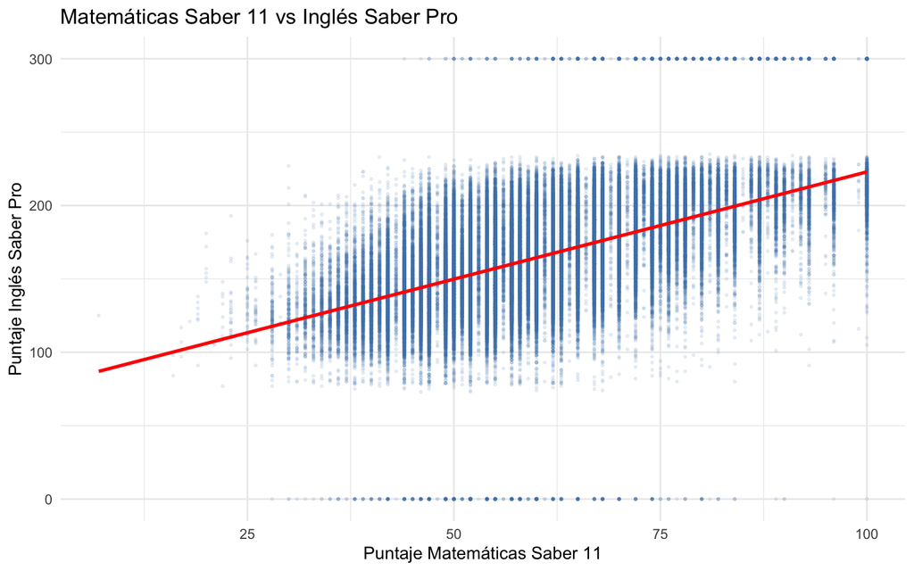

```r
ggplot(saber_pro, aes(x = PUNT_MATEMATICAS, y = MOD_INGLES_PUNT)) +
  geom_point(alpha = 0.1, color = "steelblue", size = 0.5) +
  geom_smooth(method = "lm", se = TRUE, color = "red",
              fill = "pink", alpha = 0.3) +
  labs(
    title = "Matemáticas Saber 11 vs Inglés Saber Pro",
    x = "Puntaje Matemáticas Saber 11",
    y = "Puntaje Inglés Saber Pro"
  ) +
  theme_minimal()
```

### 3.3.2 Ajustar el modelo

```r
modelo1 <- lm(MOD_INGLES_PUNT ~ PUNT_MATEMATICAS, data = saber_pro)
coef(modelo1)
```

```
##      (Intercept) PUNT_MATEMATICAS
##        76.783736         1.461469
```

**Interpretación**:

- $\hat{\beta}_0$: puntaje esperado en inglés Saber Pro si matemáticas Saber 11 = 0 (extrapolación teórica)
- $\hat{\beta}_1$: por cada punto adicional en matemáticas, esperamos ~1.46 puntos más en inglés

### 3.3.3 Ecuación estimada

$$\widehat{\text{MOD\_INGLES\_PUNT}} =
\hat{\beta}_0 + \hat{\beta}_1 \times
\text{PUNT\_MATEMATICAS}$$

```r
# Predicción para un estudiante con 60 en matemáticas
beta0 <- coef(modelo1)[1]
beta1 <- coef(modelo1)[2]
prediccion <- beta0 + beta1 * 60
cat("Predicción para PUNT_MATEMATICAS = 60:", round(prediccion, 1), "\n")
```

```
## Predicción para PUNT_MATEMATICAS = 60: 164.5
```

### 3.3.4 Resumen completo del modelo

```r
summary(modelo1)
```

```
##
## Call:
## lm(formula = MOD_INGLES_PUNT ~ PUNT_MATEMATICAS, data = saber_pro)
##
## Residuals:
##      Min       1Q   Median       3Q      Max
## -222.931  -16.473   -0.395   16.376  158.912
##
## Coefficients:
##                   Estimate Std. Error t value Pr(>|t|)
## (Intercept)      76.783736   0.377470   203.4   <2e-16 ***
## PUNT_MATEMATICAS  1.461469   0.006195   235.9   <2e-16 ***
## ---
## Signif. codes:  0 '***' 0.001 '**' 0.01 '*' 0.05 '.' 0.1 ' ' 1
##
## Residual standard error: 28.22 on 125285 degrees of freedom
##   (6 observations deleted due to missingness)
## Multiple R-squared:  0.3076, Adjusted R-squared:  0.3076
## F-statistic: 5.566e+04 on 1 and 125285 DF,  p-value: < 2.2e-16
```

### 3.3.5 Valores ajustados y residuos

```r
y_hat    <- fitted(modelo1)
residuos <- residuals(modelo1)

cat("Primeros valores ajustados:\n")
```

```
## Primeros valores ajustados:
```

```r
head(y_hat)
```

```
##        1        2        3        4        5        6
## 186.3939 192.2398 176.1636 168.8563 171.7792 182.0095
```

```r
cat("\nPrimeros residuos:\n")
```

```
##
## Primeros residuos:
```

```r
head(residuos)
```

```
##         1         2         3         4         5         6
## 12.606073 22.760196 -5.163643  3.143703 40.220765 10.990481
```

```r
cat("\nSuma de residuos (debe ser ~0):", sum(residuos), "\n")
```

```
##
## Suma de residuos (debe ser ~0): -1.602103e-08
```

```r
# Usar los datos del modelo (sin NAs) para la correlación
datos_modelo <- modelo1$model
cat("Cor(X, residuos) (debe ser ~0):", cor(datos_modelo$PUNT_MATEMATICAS, residuos), "\n")
```

```
## Cor(X, residuos) (debe ser ~0): 1.194187e-15
```

### 3.3.6 $R^2$: ¿qué tan bueno es el modelo?

$R^2$ = proporción de la variabilidad de $Y$ **explicada** por $X$.

```r
cat("R² del modelo:", summary(modelo1)$r.squared, "\n")
```

```
## R² del modelo: 0.3075927
```

```r
# Verificar con correlación
r <- cor(saber_pro$MOD_INGLES_PUNT, saber_pro$PUNT_MATEMATICAS, use = "complete.obs")
cat("r =", round(r, 4), "\n")
```

```
## r = 0.5546
```

```r
cat("r² =", round(r^2, 4), "\n")
```

```
## r² = 0.3076
```

### 3.3.7 Intervalos de confianza para los coeficientes

```r
confint(modelo1, level = 0.95)
```

```
##                      2.5 %    97.5 %
## (Intercept)      76.043901 77.523571
## PUNT_MATEMATICAS  1.449327  1.473611
```

```r
confint(modelo1, level = 0.99)
```

```
##                      0.5 %    99.5 %
## (Intercept)      75.811423 77.756049
## PUNT_MATEMATICAS  1.445512  1.477426
```

### 3.3.8 Diagnóstico: gráficos de residuos

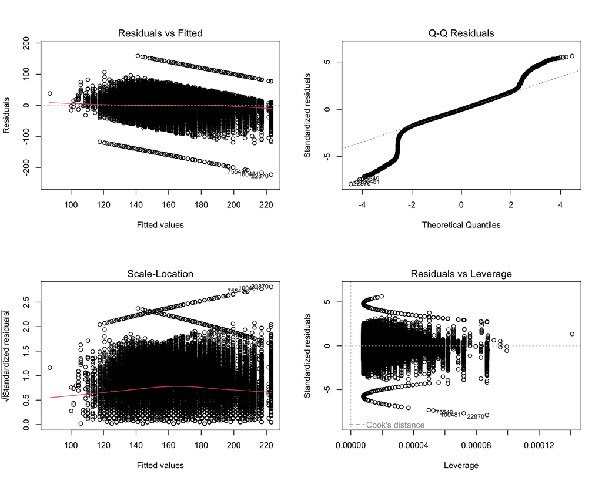

```r
par(mfrow = c(2, 2))
plot(modelo1)
```

```r
par(mfrow = c(1, 1))
```

**Lectura de los gráficos**:

1. **Residuals vs Fitted**: línea roja horizontal y dispersión uniforme $\Rightarrow$ OK
2. **Q-Q Plot**: puntos sobre la diagonal $\Rightarrow$ normalidad
3. **Scale-Location**: línea horizontal $\Rightarrow$ homocedasticidad
4. **Residuals vs Leverage**: puntos fuera de las bandas de Cook $\Rightarrow$ outliers influyentes

### 3.3.9 Verificación formal de supuestos

```r
# Normalidad (muestra de 5000 por límite de shapiro.test)
shapiro.test(sample(residuos, 5000))
```

```
##
##  Shapiro-Wilk normality test
##
## data:  sample(residuos, 5000)
## W = 0.94385, p-value < 2.2e-16
```

```r
# Homocedasticidad (Breusch-Pagan)
library(lmtest)
bptest(modelo1)
```

```
##
##  studentized Breusch-Pagan test
##
## data:  modelo1
## BP = 251.78, df = 1, p-value < 2.2e-16
```

## 3.4 Modelo con variable dummy: IES privada vs pública

### 3.4.1 ¿Qué es una variable dummy?

Una variable binaria (0/1) que representa una categoría. En economía, comparar dos grupos **es** OLS con una dummy — lo que en estadística llaman “t-test” es simplemente `lm(Y ~ D)`.

$$\text{PRIVADA} = \begin{cases} 1 &
\text{si IES privada} \\ 0 & \text{si IES pública}
\end{cases}$$

```r
saber_pro$PRIVADA <- ifelse(saber_pro$TIPO_IES == "Privada", 1, 0)
table(saber_pro$PRIVADA)
```

```
##
##     0     1
## 39182 86111
```

### 3.4.2 Ajustar modelo con dummy

```r
modelo_dummy <- lm(MOD_INGLES_PUNT ~ PRIVADA, data = saber_pro)
summary(modelo_dummy)
```

```
##
## Call:
## lm(formula = MOD_INGLES_PUNT ~ PRIVADA, data = saber_pro)
##
## Residuals:
##      Min       1Q   Median       3Q      Max
## -165.755  -22.755   -0.755   22.245  140.414
##
## Coefficients:
##             Estimate Std. Error t value Pr(>|t|)
## (Intercept) 159.5864     0.1707  934.75   <2e-16 ***
## PRIVADA       6.1683     0.2059   29.95   <2e-16 ***
## ---
## Signif. codes:  0 '***' 0.001 '**' 0.01 '*' 0.05 '.' 0.1 ' ' 1
##
## Residual standard error: 33.79 on 125285 degrees of freedom
##   (6 observations deleted due to missingness)
## Multiple R-squared:  0.00711,    Adjusted R-squared:  0.007102
## F-statistic: 897.2 on 1 and 125285 DF,  p-value: < 2.2e-16
```

**Interpretación**:

- $\hat{\beta}_0$: puntaje promedio en IES **públicas**
- $\hat{\beta}_1$: diferencia promedio entre IES privadas y públicas
- $\hat{\beta}_0 + \hat{\beta}_1$: puntaje promedio en IES **privadas**

### 3.4.3 Verificación: OLS con dummy = “t-test”

El `lm()` con una dummy produce el **mismo** estadístico t que `t.test()`. No son dos métodos — son dos formas de escribir lo mismo:

```r
t.test(MOD_INGLES_PUNT ~ TIPO_IES, data = saber_pro, var.equal = TRUE)
```

```
##
##  Two Sample t-test
##
## data:  MOD_INGLES_PUNT by TIPO_IES
## t = 29.953, df = 125285, p-value < 2.2e-16
## alternative hypothesis: true difference in means between group Privada and group Publica is not equal to 0
## 95 percent confidence interval:
##  5.764708 6.571965
## sample estimates:
## mean in group Privada mean in group Publica
##              165.7548              159.5864
```

> Mismo $t$, mismo p-valor, misma conclusión. En economía usamos siempre `lm()`, que además generaliza a múltiples regresores.

### 3.4.4 Visualización

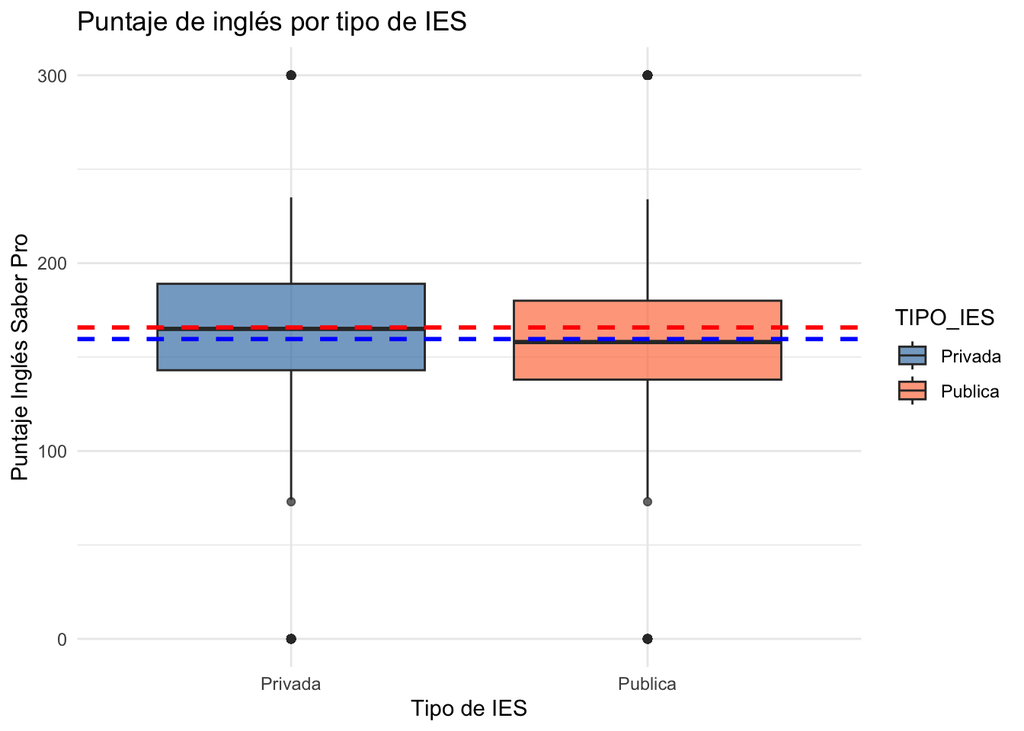

```r
ggplot(saber_pro, aes(x = TIPO_IES, y = MOD_INGLES_PUNT, fill = TIPO_IES)) +
  geom_boxplot(alpha = 0.7) +
  geom_hline(yintercept = coef(modelo_dummy)[1],
             linetype = "dashed", color = "blue", linewidth = 1) +
  geom_hline(yintercept = coef(modelo_dummy)[1] + coef(modelo_dummy)[2],
             linetype = "dashed", color = "red", linewidth = 1) +
  labs(
    title = "Puntaje de inglés por tipo de IES",
    x = "Tipo de IES",
    y = "Puntaje Inglés Saber Pro"
  ) +
  scale_fill_manual(values = c("steelblue", "coral")) +
  theme_minimal()
```

## 3.5 Modelo 2 (integrador): Inglés (Saber 11) → Razonamiento Cuantitativo (Saber Pro)

### 3.5.1 Paso 1: Exploración

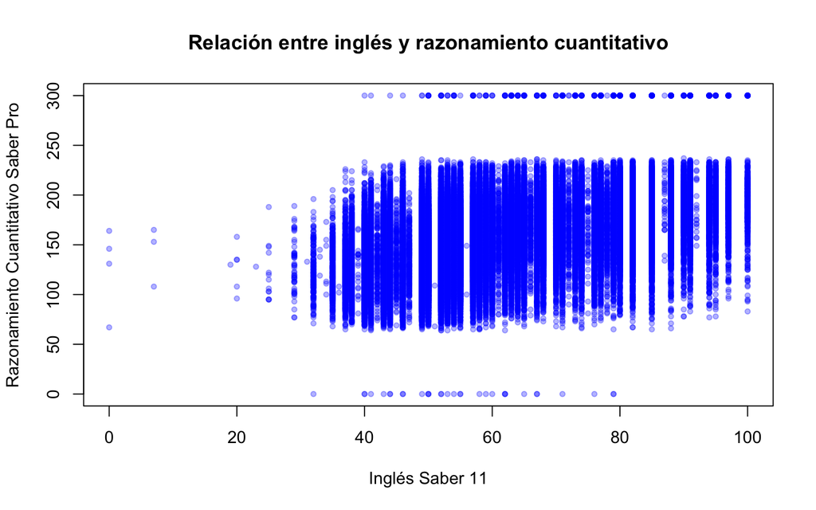

```r
plot(saber_pro$PUNT_INGLES,
     saber_pro$MOD_RAZONA_CUANTITAT_PUNT,
     xlab = "Inglés Saber 11",
     ylab = "Razonamiento Cuantitativo Saber Pro",
     main = "Relación entre inglés y razonamiento cuantitativo",
     pch = 20, col = rgb(0, 0, 1, 0.3))
```

### 3.5.2 Paso 2: Correlación

```r
cor(saber_pro$PUNT_INGLES,
    saber_pro$MOD_RAZONA_CUANTITAT_PUNT,
    use = "complete.obs")
```

```
## [1] 0.4669563
```

### 3.5.3 Paso 3: Ajustar modelo

```r
modelo2 <- lm(MOD_RAZONA_CUANTITAT_PUNT ~ PUNT_INGLES, data = saber_pro)
summary(modelo2)
```

```
##
## Call:
## lm(formula = MOD_RAZONA_CUANTITAT_PUNT ~ PUNT_INGLES, data = saber_pro)
##
## Residuals:
##      Min       1Q   Median       3Q      Max
## -174.870  -18.970    0.379   19.079  167.054
##
## Coefficients:
##              Estimate Std. Error t value Pr(>|t|)
## (Intercept) 89.948318   0.349515   257.4   <2e-16 ***
## PUNT_INGLES  1.074954   0.005751   186.9   <2e-16 ***
## ---
## Signif. codes:  0 '***' 0.001 '**' 0.01 '*' 0.05 '.' 0.1 ' ' 1
##
## Residual standard error: 28.99 on 125291 degrees of freedom
## Multiple R-squared:  0.218,  Adjusted R-squared:  0.218
## F-statistic: 3.494e+04 on 1 and 125291 DF,  p-value: < 2.2e-16
```

### 3.5.4 Paso 4: Intervalos de confianza

```r
confint(modelo2)
```

```
##                 2.5 %    97.5 %
## (Intercept) 89.263275 90.633362
## PUNT_INGLES  1.063682  1.086226
```

### 3.5.5 Paso 5: Diagnóstico

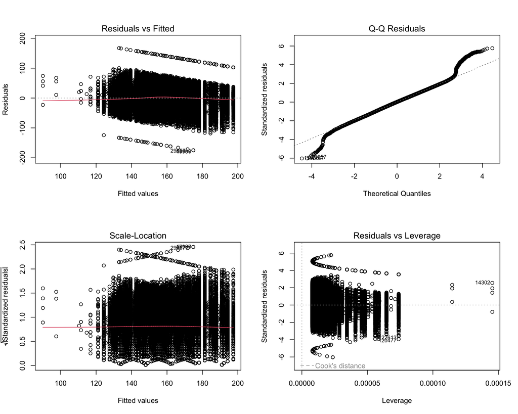

```r
par(mfrow = c(2, 2))
plot(modelo2)
```

```r
par(mfrow = c(1, 1))
```

```r
# Normalidad
shapiro.test(sample(residuals(modelo2), 5000))
```

```
##
##  Shapiro-Wilk normality test
##
## data:  sample(residuals(modelo2), 5000)
## W = 0.99426, p-value = 2.989e-13
```

```r
# Homocedasticidad
bptest(modelo2)
```

```
##
##  studentized Breusch-Pagan test
##
## data:  modelo2
## BP = 277, df = 1, p-value < 2.2e-16
```

### 3.5.6 Paso 6: Predicción

```r
nuevo_dato <- data.frame(PUNT_INGLES = 60)

# Predicción puntual
predict(modelo2, newdata = nuevo_dato)
```

```
##        1
## 154.4456
```

```r
# Intervalo de confianza (para la media)
predict(modelo2, newdata = nuevo_dato, interval = "confidence")
```

```
##        fit      lwr      upr
## 1 154.4456 154.2847 154.6064
```

```r
# Intervalo de predicción (para una observación individual)
predict(modelo2, newdata = nuevo_dato, interval = "prediction")
```

```
##        fit      lwr      upr
## 1 154.4456 97.63005 211.2611
```

> **Diferencia**: el IC es para la **media** de $Y$ dado $X$, el IP es para una **observación individual**. El IP siempre es más amplio.

### 3.5.7 Paso 7: Visualización final

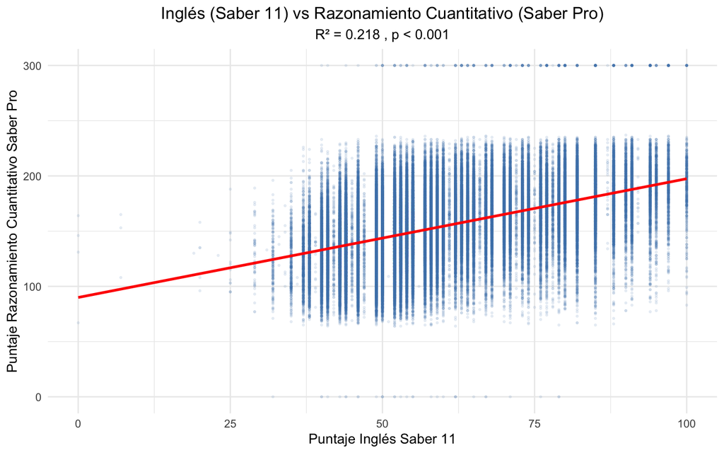

```r
ggplot(saber_pro, aes(x = PUNT_INGLES, y = MOD_RAZONA_CUANTITAT_PUNT)) +
  geom_point(alpha = 0.1, color = "steelblue", size = 0.5) +
  geom_smooth(method = "lm", se = TRUE, color = "red",
              fill = "pink", alpha = 0.3) +
  labs(
    title = "Inglés (Saber 11) vs Razonamiento Cuantitativo (Saber Pro)",
    subtitle = paste("R² =", round(summary(modelo2)$r.squared, 3), ", p < 0.001"),
    x = "Puntaje Inglés Saber 11",
    y = "Puntaje Razonamiento Cuantitativo Saber Pro"
  ) +
  theme_minimal() +
  theme(
    plot.title = element_text(hjust = 0.5),
    plot.subtitle = element_text(hjust = 0.5)
  )
```

# 4 Resumen

## 4.1 Todo es OLS (excepto $\chi^2$)

| Tipo de $X$ | Modelo OLS | Nombre en estadística |
| --- | --- | --- |
| 1 dummy | $Y = \beta_0 + \beta_1 D + \varepsilon$ | “t-test” |
| $k$ dummies | $Y = \beta_0 + \sum \beta_j D_j + \varepsilon$ | “ANOVA” |
| Continua | $Y = \beta_0 + \beta_1 X + \varepsilon$ | Regresión simple |
| Dummies + continuas | $Y = \beta_0 + \beta_1 X + \beta_2 D + \varepsilon$ | “ANCOVA” |
| **Ambas categóricas** | **No es OLS** → $\chi^2$ | Chi-cuadrado |

## 4.2 Siempre reportar

- **Coeficientes** + errores estándar + p-valor
- **$R^2$** (o V de Cramér para $\chi^2$)
- **Interpretación en contexto**: qué significa $\hat{\beta}_1$ en las unidades del problema

## 4.3 Próxima sesión

OLS **múltiple**: $Y_i = \beta_0 + \beta_1 X_{1i} + \beta_2 X_{2i} + \cdots + \beta_k X_{ki} + \varepsilon_i$. Dummies + continuas en el mismo modelo.